# Predict Bike Sharing Demand with AutoGluon Template

## Project: Predict Bike Sharing Demand with AutoGluon

This notebook is a template with each step that you need to complete for the project.

Please fill in your code where there are explicit `?` markers in the notebook. You are welcome to add more cells and code as you see fit.

Once you have completed all the code implementations, please export your notebook as a HTML file so the reviews can view your code. Make sure you have all outputs correctly outputted.

`File-> Export Notebook As... -> Export Notebook as HTML`

There is a writeup to complete as well after all code implememtation is done. Please answer all questions and attach the necessary tables and charts. You can complete the writeup in either markdown or PDF.

Completing the code template and writeup template will cover all of the rubric points for this project.

The rubric contains "Stand Out Suggestions" for enhancing the project beyond the minimum requirements. The stand out suggestions are optional. If you decide to pursue the "stand out suggestions", you can include the code in this notebook and also discuss the results in the writeup file.

## Step 1: Create an account with Kaggle

### Create Kaggle Account and download API key

Below is example of steps to get the API username and key. Each student will have their own username and key.

1. Open account settings.

2. Scroll down to API and click Create New API Token.

3. Open up `kaggle.json` and use the username and key.


## Step 2: Download the Kaggle dataset using the kaggle python library

### Install packages

```python
!pip install kaggle
!pip install --upgrade ipywidgets
!pip install autogluon
# Without --no-cache-dir, smaller aws instances may have trouble installing
```

### Setup Kaggle API Key

```python
import os
import json

# Create the .kaggle directory if it doesn't exist
os.makedirs('/root/.kaggle', exist_ok=True)

# Assuming you have your kaggle.json content as a dictionary
kaggle_json_content = {
    "username": "lobnah",
    "key": "d8360e73037a26d26f7493abf58e72c3"
}

# Write the kaggle.json content to the file
with open('/root/.kaggle/kaggle.json', 'w') as f:
    json.dump(kaggle_json_content, f)

# Change the file permission to 600
os.chmod('/root/.kaggle/kaggle.json', 0o600)
```

```python
# create the .kaggle directory and an empty kaggle.json file
# Create a .kaggle directory in the current user's home directory
'''!mkdir -p ~/.kaggle

# Create the kaggle.json file inside the .kaggle directory
!touch ~/.kaggle/kaggle.json

# Set the permissions of the kaggle.json file to be read and written by the user only
!chmod 600 ~/.kaggle/kaggle.json'''
```

[output not shown]

```python
# Fill in your user name and key from creating the kaggle account and API token file
'''import json
kaggle_username = "lobnah"
kaggle_key = "d8360e73037a26d26f7493abf58e72c3"

# Save API token the kaggle.json file
with open("/root/.kaggle/kaggle.json", "w") as f:
    f.write(json.dumps({"username": kaggle_username, "key": kaggle_key}))'''
```

[output not shown]

### Download and explore dataset

### Go to the bike sharing demand competition and agree to the terms

```python
# Download the dataset, it will be in a .zip file so you'll need to unzip it as well.
#!kaggle competitions download -c bike-sharing-demand
# If you already downloaded it you can use the -o command to overwrite the file
#!unzip -o bike-sharing-demand.zip
```

```python
import pandas as pd
from autogluon.tabular import TabularPredictor
```

```python
# Create the train dataset in pandas by reading the csv
# Set the parsing of the datetime column so you can use some of the `dt` features in pandas later
train = pd.read_csv('train.csv')
train['datetime'] = pd.to_datetime(train['datetime'])
train.head()
```

|  | datetime | season | holiday | workingday | weather | temp | atemp | humidity | windspeed | casual | registered | count |
| --- | --- | --- | --- | --- | --- | --- | --- | --- | --- | --- | --- | --- |
| 0 | 2011-01-01 00:00:00 | 1 | 0 | 0 | 1 | 9.84 | 14.395 | 81 | 0.0 | 3 | 13 | 16 |
| 1 | 2011-01-01 01:00:00 | 1 | 0 | 0 | 1 | 9.02 | 13.635 | 80 | 0.0 | 8 | 32 | 40 |
| 2 | 2011-01-01 02:00:00 | 1 | 0 | 0 | 1 | 9.02 | 13.635 | 80 | 0.0 | 5 | 27 | 32 |
| 3 | 2011-01-01 03:00:00 | 1 | 0 | 0 | 1 | 9.84 | 14.395 | 75 | 0.0 | 3 | 10 | 13 |
| 4 | 2011-01-01 04:00:00 | 1 | 0 | 0 | 1 | 9.84 | 14.395 | 75 | 0.0 | 0 | 1 | 1 |

```python
# Simple output of the train dataset to view some of the min/max/varition of the dataset features.
train.describe()
```

|  | datetime | season | holiday | workingday | weather | temp | atemp | humidity | windspeed | casual | registered | count |
| --- | --- | --- | --- | --- | --- | --- | --- | --- | --- | --- | --- | --- |
| count | 10886 | 10886.000000 | 10886.000000 | 10886.000000 | 10886.000000 | 10886.00000 | 10886.000000 | 10886.000000 | 10886.000000 | 10886.000000 | 10886.000000 | 10886.000000 |
| mean | 2011-12-27 05:56:22.399411968 | 2.506614 | 0.028569 | 0.680875 | 1.418427 | 20.23086 | 23.655084 | 61.886460 | 12.799395 | 36.021955 | 155.552177 | 191.574132 |
| min | 2011-01-01 00:00:00 | 1.000000 | 0.000000 | 0.000000 | 1.000000 | 0.82000 | 0.760000 | 0.000000 | 0.000000 | 0.000000 | 0.000000 | 1.000000 |
| 25% | 2011-07-02 07:15:00 | 2.000000 | 0.000000 | 0.000000 | 1.000000 | 13.94000 | 16.665000 | 47.000000 | 7.001500 | 4.000000 | 36.000000 | 42.000000 |
| 50% | 2012-01-01 20:30:00 | 3.000000 | 0.000000 | 1.000000 | 1.000000 | 20.50000 | 24.240000 | 62.000000 | 12.998000 | 17.000000 | 118.000000 | 145.000000 |
| 75% | 2012-07-01 12:45:00 | 4.000000 | 0.000000 | 1.000000 | 2.000000 | 26.24000 | 31.060000 | 77.000000 | 16.997900 | 49.000000 | 222.000000 | 284.000000 |
| max | 2012-12-19 23:00:00 | 4.000000 | 1.000000 | 1.000000 | 4.000000 | 41.00000 | 45.455000 | 100.000000 | 56.996900 | 367.000000 | 886.000000 | 977.000000 |
| std | NaN | 1.116174 | 0.166599 | 0.466159 | 0.633839 | 7.79159 | 8.474601 | 19.245033 | 8.164537 | 49.960477 | 151.039033 | 181.144454 |

```python
# Create the test pandas dataframe in pandas by reading the csv, remember to parse the datetime!
test = pd.read_csv('test.csv')
test['datetime'] = pd.to_datetime(test['datetime'])
test.head()
```

|  | datetime | season | holiday | workingday | weather | temp | atemp | humidity | windspeed |
| --- | --- | --- | --- | --- | --- | --- | --- | --- | --- |
| 0 | 2011-01-20 00:00:00 | 1 | 0 | 1 | 1 | 10.66 | 11.365 | 56 | 26.0027 |
| 1 | 2011-01-20 01:00:00 | 1 | 0 | 1 | 1 | 10.66 | 13.635 | 56 | 0.0000 |
| 2 | 2011-01-20 02:00:00 | 1 | 0 | 1 | 1 | 10.66 | 13.635 | 56 | 0.0000 |
| 3 | 2011-01-20 03:00:00 | 1 | 0 | 1 | 1 | 10.66 | 12.880 | 56 | 11.0014 |
| 4 | 2011-01-20 04:00:00 | 1 | 0 | 1 | 1 | 10.66 | 12.880 | 56 | 11.0014 |

```python
train = train.drop(["casual", "registered"], axis=1)
```

```python
train.head()
```

|  | datetime | season | holiday | workingday | weather | temp | atemp | humidity | windspeed | count |
| --- | --- | --- | --- | --- | --- | --- | --- | --- | --- | --- |
| 0 | 2011-01-01 00:00:00 | 1 | 0 | 0 | 1 | 9.84 | 14.395 | 81 | 0.0 | 16 |
| 1 | 2011-01-01 01:00:00 | 1 | 0 | 0 | 1 | 9.02 | 13.635 | 80 | 0.0 | 40 |
| 2 | 2011-01-01 02:00:00 | 1 | 0 | 0 | 1 | 9.02 | 13.635 | 80 | 0.0 | 32 |
| 3 | 2011-01-01 03:00:00 | 1 | 0 | 0 | 1 | 9.84 | 14.395 | 75 | 0.0 | 13 |
| 4 | 2011-01-01 04:00:00 | 1 | 0 | 0 | 1 | 9.84 | 14.395 | 75 | 0.0 | 1 |

```python
# Same thing as train and test dataset
submission = pd.read_csv('sampleSubmission.csv')
submission['datetime'] = pd.to_datetime(submission['datetime'])
submission.head()
```

|  | datetime | count |
| --- | --- | --- |
| 0 | 2011-01-20 00:00:00 | 0 |
| 1 | 2011-01-20 01:00:00 | 0 |
| 2 | 2011-01-20 02:00:00 | 0 |
| 3 | 2011-01-20 03:00:00 | 0 |
| 4 | 2011-01-20 04:00:00 | 0 |

## Step 3: Train a model using AutoGluon’s Tabular Prediction

Requirements:

- We are prediting `count`, so it is the label we are setting.
- Ignore `casual` and `registered` columns as they are also not present in the test dataset.
- Use the `root_mean_squared_error` as the metric to use for evaluation.
- Set a time limit of 10 minutes (600 seconds).
- Use the preset `best_quality` to focus on creating the best model.

```python
predictor = TabularPredictor(label="count").fit(train_data=train, time_limit=600, presets="best_quality")
```

```
No path specified. Models will be saved in: "AutogluonModels\ag-20240509_135112"
Presets specified: ['best_quality']
Setting dynamic_stacking from 'auto' to True. Reason: Enable dynamic_stacking when use_bag_holdout is disabled. (use_bag_holdout=False)
Stack configuration (auto_stack=True): num_stack_levels=1, num_bag_folds=8, num_bag_sets=1
Dynamic stacking is enabled (dynamic_stacking=True). AutoGluon will try to determine whether the input data is affected by stacked overfitting and enable or disable stacking as a consequence.
Detecting stacked overfitting by sub-fitting AutoGluon on the input data. That is, copies of AutoGluon will be sub-fit on subset(s) of the data. Then, the holdout validation data is used to detect stacked overfitting.
Sub-fit(s) time limit is: 600 seconds.
Starting holdout-based sub-fit for dynamic stacking. Context path is: AutogluonModels\ag-20240509_135112\ds_sub_fit\sub_fit_ho.
Running the sub-fit in a ray process to avoid memory leakage.
Spend 174 seconds for the sub-fit(s) during dynamic stacking.
Time left for full fit of AutoGluon: 426 seconds.
Starting full fit now with num_stack_levels 1.
Beginning AutoGluon training ... Time limit = 426s
AutoGluon will save models to "AutogluonModels\ag-20240509_135112"
=================== System Info ===================
AutoGluon Version:  1.1.0
Python Version:     3.11.5
Operating System:   Windows
Platform Machine:   AMD64
Platform Version:   10.0.22631
CPU Count:          12
Memory Avail:       5.19 GB / 15.74 GB (33.0%)
Disk Space Avail:   11.35 GB / 201.59 GB (5.6%)
===================================================
Train Data Rows:    10886
Train Data Columns: 9
Label Column:       count
Problem Type:       regression
Preprocessing data ...
Using Feature Generators to preprocess the data ...
Fitting AutoMLPipelineFeatureGenerator...
	Available Memory:                    5315.76 MB
	Train Data (Original)  Memory Usage: 0.75 MB (0.0% of available memory)
	Inferring data type of each feature based on column values. Set feature_metadata_in to manually specify special dtypes of the features.
	Stage 1 Generators:
		Fitting AsTypeFeatureGenerator...
			Note: Converting 2 features to boolean dtype as they only contain 2 unique values.
	Stage 2 Generators:
		Fitting FillNaFeatureGenerator...
	Stage 3 Generators:
```

[output cut: 108 more lines]

```
	-53.9033	 = Validation score   (-root_mean_squared_error)
	7.43s	 = Training   runtime
	0.48s	 = Validation runtime
Fitting model: NeuralNetFastAI_BAG_L2 ... Training model for up to 7.14s of the 7.05s of remaining time.
	Fitting 8 child models (S1F1 - S1F8) | Fitting with ParallelLocalFoldFittingStrategy (8 workers, per: cpus=1, gpus=0, memory=0.32%)
	-57.809	 = Validation score   (-root_mean_squared_error)
	14.47s	 = Training   runtime
	0.34s	 = Validation runtime
Fitting model: WeightedEnsemble_L3 ... Training model for up to 360.0s of the -14.71s of remaining time.
	Ensemble Weights: {'RandomForestMSE_BAG_L2': 0.545, 'ExtraTreesMSE_BAG_L2': 0.227, 'NeuralNetFastAI_BAG_L2': 0.136, 'LightGBM_BAG_L2': 0.091}
	-52.518	 = Validation score   (-root_mean_squared_error)
	0.13s	 = Training   runtime
	0.0s	 = Validation runtime
AutoGluon training complete, total runtime = 440.9s ... Best model: "WeightedEnsemble_L3"
TabularPredictor saved. To load, use: predictor = TabularPredictor.load("AutogluonModels\ag-20240509_135112")
```

### Review AutoGluon's training run with ranking of models that did the best.

```python
predictor.fit_summary()
```

```
*** Summary of fit() ***
Estimated performance of each model:
                     model   score_val              eval_metric  pred_time_val    fit_time  pred_time_val_marginal  fit_time_marginal  stack_level  can_infer  fit_order
0      WeightedEnsemble_L3  -52.518016  root_mean_squared_error      15.933216  310.568225                0.004000           0.128623            3       True         18
1   RandomForestMSE_BAG_L2  -53.143166  root_mean_squared_error      14.790639  281.152921                0.470193          28.645183            2       True         14
2     ExtraTreesMSE_BAG_L2  -53.903339  root_mean_squared_error      14.800125  259.942451                0.479680           7.434713            2       True         16
3          LightGBM_BAG_L2  -54.933745  root_mean_squared_error      14.644147  259.886319                0.323701           7.378581            2       True         13
4          CatBoost_BAG_L2  -55.618124  root_mean_squared_error      14.371448  293.102485                0.051003          40.594746            2       True         15
5   NeuralNetFastAI_BAG_L2  -57.809042  root_mean_squared_error      14.655641  266.981127                0.335195          14.473388            2       True         17
6        LightGBMXT_BAG_L2  -60.113258  root_mean_squared_error      18.846301  269.477309                4.525856          16.969571            2       True         12
7    KNeighborsDist_BAG_L1  -84.169493  root_mean_squared_error       0.032000    0.014472                0.032000           0.014472            1       True          2
8      WeightedEnsemble_L2  -84.169493  root_mean_squared_error       0.034002    0.082549                0.002002           0.068077            2       True         11
9    KNeighborsUnif_BAG_L1 -101.632965  root_mean_squared_error       0.030516    0.417673                0.030516           0.417673            1       True          1
10  RandomForestMSE_BAG_L1 -116.552091  root_mean_squared_error       0.426088    7.711087                0.426088           7.711087            1       True          5
11    ExtraTreesMSE_BAG_L1 -124.602302  root_mean_squared_error       0.474592    3.093733                0.474592           3.093733            1       True          7
12         CatBoost_BAG_L1 -130.461205  root_mean_squared_error       0.051668  162.574075                0.051668         162.574075            1       True          6
13         LightGBM_BAG_L1 -131.054162  root_mean_squared_error       1.223377    9.568425                1.223377           9.568425            1       True          4
14       LightGBMXT_BAG_L1 -131.460909  root_mean_squared_error      11.058453   20.247071               11.058453          20.247071            1       True          3
15          XGBoost_BAG_L1 -131.893935  root_mean_squared_error       0.530315    6.703063                0.530315           6.703063            1       True          9
16  NeuralNetFastAI_BAG_L1 -136.266320  root_mean_squared_error       0.335689   29.798066                0.335689          29.798066            1       True          8
17   NeuralNetTorch_BAG_L1 -148.520265  root_mean_squared_error       0.157749   12.380071                0.157749          12.380071            1       True         10
Number of models trained: 18
Types of models trained:
{'WeightedEnsembleModel', 'StackerEnsembleModel_NNFastAiTabular', 'StackerEnsembleModel_XT', 'StackerEnsembleModel_XGBoost', 'StackerEnsembleModel_LGB', 'StackerEnsembleModel_CatBoost', 'StackerEnsembleModel_RF', 'StackerEnsembleModel_TabularNeuralNetTorch', 'StackerEnsembleModel_KNN'}
Bagging used: True  (with 8 folds)
Multi-layer stack-ensembling used: True  (with 3 levels)
Feature Metadata (Processed):
(raw dtype, special dtypes):
('float', [])                : 3 | ['temp', 'atemp', 'windspeed']
('int', [])                  : 3 | ['season', 'weather', 'humidity']
('int', ['bool'])            : 2 | ['holiday', 'workingday']
('int', ['datetime_as_int']) : 5 | ['datetime', 'datetime.year', 'datetime.month', 'datetime.day', 'datetime.dayofweek']
Plot summary of models saved to file: AutogluonModels\ag-20240509_135112SummaryOfModels.html
*** End of fit() summary ***
```

[output not shown]

[output cut: 175 more lines]

[output not shown]

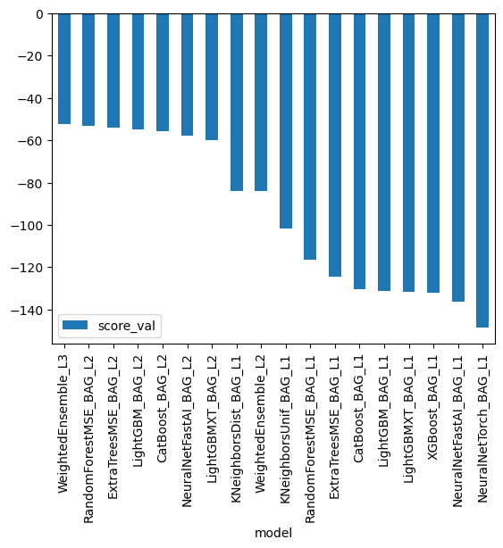

```python
predictor.leaderboard(silent=True).plot(kind="bar", x="model", y="score_val")
```

### Create predictions from test dataset

```python
predictions = predictor.predict(test)
predictions.head()
```

```
0    30.362080
1    45.408821
2    50.913227
3    55.599869
4    57.964916
Name: count, dtype: float32
```

#### NOTE: Kaggle will reject the submission if we don't set everything to be > 0.

```python
# Describe the `predictions` series to see if there are any negative values
predictions.describe()
```

```
count    6493.000000
mean      121.774208
std       113.146530
min         3.345732
25%        24.337269
50%        74.435089
75%       203.972656
max       436.671204
Name: count, dtype: float64
```

```python
# How many negative values do we have?
sum(predictions[predictions < 0])
```

```
0
```

```python
# Set them to zero
predictions[predictions < 0] = 0
```

### Set predictions to submission dataframe, save, and submit

```python
submission["count"] = predictions
submission.to_csv("submission.csv", index=False)
```

```python
!kaggle competitions submit -c bike-sharing-demand -f submission.csv -m "first raw submission"
```

```
Successfully submitted to Bike Sharing Demand
```

```
  4%|4         | 8.00k/194k [00:00<00:11, 16.3kB/s]
 70%|######9   | 136k/194k [00:00<00:00, 282kB/s]
```

#### View submission via the command line or in the web browser under the competition's page - `My Submissions`

```python
!kaggle competitions submissions -c bike-sharing-demand | tail -n +1 | head -n 6
```

[output not shown]

## Step 4: Exploratory Data Analysis and Creating an additional feature

- Any additional feature will do, but a great suggestion would be to separate out the datetime into hour, day, or month parts.

```
array([[<Axes: title={'center': 'datetime'}>,
        <Axes: title={'center': 'season'}>,
        <Axes: title={'center': 'holiday'}>],
       [<Axes: title={'center': 'workingday'}>,
        <Axes: title={'center': 'weather'}>,
        <Axes: title={'center': 'temp'}>],
       [<Axes: title={'center': 'atemp'}>,
        <Axes: title={'center': 'humidity'}>,
        <Axes: title={'center': 'windspeed'}>],
       [<Axes: title={'center': 'count'}>, <Axes: >, <Axes: >]],
      dtype=object)
```

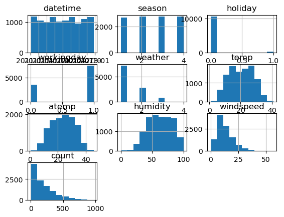

```python
# Create a histogram of all features to show the distribution of each one relative to the data. This is part of the exploritory data analysis
train.hist()
```

```python
# create a new feature
train["year"] = train["datetime"].dt.year
train["month"] = train["datetime"].dt.month
train["day"] = train["datetime"].dt.day
train["hour"] = train["datetime"].dt.hour
```

```python
train.head()
```

|  | datetime | season | holiday | workingday | weather | temp | atemp | humidity | windspeed | count | year | month | day | hour |
| --- | --- | --- | --- | --- | --- | --- | --- | --- | --- | --- | --- | --- | --- | --- |
| 0 | 2011-01-01 00:00:00 | 1 | 0 | 0 | 1 | 9.84 | 14.395 | 81 | 0.0 | 16 | 2011 | 1 | 1 | 0 |
| 1 | 2011-01-01 01:00:00 | 1 | 0 | 0 | 1 | 9.02 | 13.635 | 80 | 0.0 | 40 | 2011 | 1 | 1 | 1 |
| 2 | 2011-01-01 02:00:00 | 1 | 0 | 0 | 1 | 9.02 | 13.635 | 80 | 0.0 | 32 | 2011 | 1 | 1 | 2 |
| 3 | 2011-01-01 03:00:00 | 1 | 0 | 0 | 1 | 9.84 | 14.395 | 75 | 0.0 | 13 | 2011 | 1 | 1 | 3 |
| 4 | 2011-01-01 04:00:00 | 1 | 0 | 0 | 1 | 9.84 | 14.395 | 75 | 0.0 | 1 | 2011 | 1 | 1 | 4 |

```python
test["year"] = test["datetime"].dt.year
test["month"] = test["datetime"].dt.month
test["day"] = test["datetime"].dt.day
test["hour"] = test["datetime"].dt.hour
```

```python
test.head()
```

|  | datetime | season | holiday | workingday | weather | temp | atemp | humidity | windspeed | year | month | day | hour |
| --- | --- | --- | --- | --- | --- | --- | --- | --- | --- | --- | --- | --- | --- |
| 0 | 2011-01-20 00:00:00 | 1 | 0 | 1 | 1 | 10.66 | 11.365 | 56 | 26.0027 | 2011 | 1 | 20 | 0 |
| 1 | 2011-01-20 01:00:00 | 1 | 0 | 1 | 1 | 10.66 | 13.635 | 56 | 0.0000 | 2011 | 1 | 20 | 1 |
| 2 | 2011-01-20 02:00:00 | 1 | 0 | 1 | 1 | 10.66 | 13.635 | 56 | 0.0000 | 2011 | 1 | 20 | 2 |
| 3 | 2011-01-20 03:00:00 | 1 | 0 | 1 | 1 | 10.66 | 12.880 | 56 | 11.0014 | 2011 | 1 | 20 | 3 |
| 4 | 2011-01-20 04:00:00 | 1 | 0 | 1 | 1 | 10.66 | 12.880 | 56 | 11.0014 | 2011 | 1 | 20 | 4 |

## Make category types for these so models know they are not just numbers

- AutoGluon originally sees these as ints, but in reality they are int representations of a category.
- Setting the dtype to category will classify these as categories in AutoGluon.

```python
train["season"] = train["season"].astype('category')
train["weather"] = train["weather"].astype('category')
test["season"] = test["season"].astype('category')
test["weather"] = test["weather"].astype('category')
```

```python
# View are new feature
train.head()
```

|  | datetime | season | holiday | workingday | weather | temp | atemp | humidity | windspeed | count | year | month | day | hour |
| --- | --- | --- | --- | --- | --- | --- | --- | --- | --- | --- | --- | --- | --- | --- |
| 0 | 2011-01-01 00:00:00 | 1 | 0 | 0 | 1 | 9.84 | 14.395 | 81 | 0.0 | 16 | 2011 | 1 | 1 | 0 |
| 1 | 2011-01-01 01:00:00 | 1 | 0 | 0 | 1 | 9.02 | 13.635 | 80 | 0.0 | 40 | 2011 | 1 | 1 | 1 |
| 2 | 2011-01-01 02:00:00 | 1 | 0 | 0 | 1 | 9.02 | 13.635 | 80 | 0.0 | 32 | 2011 | 1 | 1 | 2 |
| 3 | 2011-01-01 03:00:00 | 1 | 0 | 0 | 1 | 9.84 | 14.395 | 75 | 0.0 | 13 | 2011 | 1 | 1 | 3 |
| 4 | 2011-01-01 04:00:00 | 1 | 0 | 0 | 1 | 9.84 | 14.395 | 75 | 0.0 | 1 | 2011 | 1 | 1 | 4 |

```
array([[<Axes: title={'center': 'datetime'}>,
        <Axes: title={'center': 'holiday'}>,
        <Axes: title={'center': 'workingday'}>],
       [<Axes: title={'center': 'temp'}>,
        <Axes: title={'center': 'atemp'}>,
        <Axes: title={'center': 'humidity'}>],
       [<Axes: title={'center': 'windspeed'}>,
        <Axes: title={'center': 'count'}>,
        <Axes: title={'center': 'year'}>],
       [<Axes: title={'center': 'month'}>,
        <Axes: title={'center': 'day'}>,
        <Axes: title={'center': 'hour'}>]], dtype=object)
```

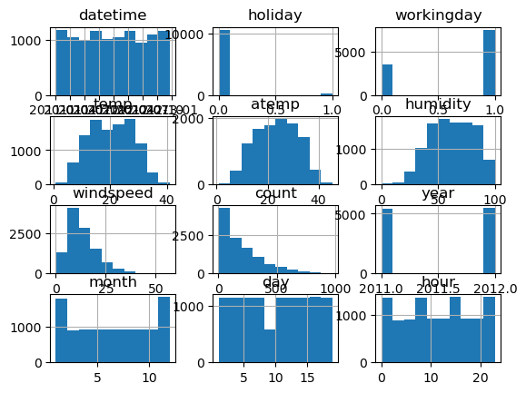

```python
# View histogram of all features again now with the hour feature
train.hist()
```

## Step 5: Rerun the model with the same settings as before, just with more features

```python
predictor_new_features = TabularPredictor(label="count").fit(train_data=train, time_limit=600, presets="best_quality")
```

```
No path specified. Models will be saved in: "AutogluonModels\ag-20240509_140151"
Presets specified: ['best_quality']
Setting dynamic_stacking from 'auto' to True. Reason: Enable dynamic_stacking when use_bag_holdout is disabled. (use_bag_holdout=False)
Stack configuration (auto_stack=True): num_stack_levels=1, num_bag_folds=8, num_bag_sets=1
Dynamic stacking is enabled (dynamic_stacking=True). AutoGluon will try to determine whether the input data is affected by stacked overfitting and enable or disable stacking as a consequence.
Detecting stacked overfitting by sub-fitting AutoGluon on the input data. That is, copies of AutoGluon will be sub-fit on subset(s) of the data. Then, the holdout validation data is used to detect stacked overfitting.
Sub-fit(s) time limit is: 600 seconds.
Starting holdout-based sub-fit for dynamic stacking. Context path is: AutogluonModels\ag-20240509_140151\ds_sub_fit\sub_fit_ho.
Running the sub-fit in a ray process to avoid memory leakage.
Spend 162 seconds for the sub-fit(s) during dynamic stacking.
Time left for full fit of AutoGluon: 438 seconds.
Starting full fit now with num_stack_levels 1.
Beginning AutoGluon training ... Time limit = 438s
AutoGluon will save models to "AutogluonModels\ag-20240509_140151"
=================== System Info ===================
AutoGluon Version:  1.1.0
Python Version:     3.11.5
Operating System:   Windows
Platform Machine:   AMD64
Platform Version:   10.0.22631
CPU Count:          12
Memory Avail:       4.73 GB / 15.74 GB (30.0%)
Disk Space Avail:   9.45 GB / 201.59 GB (4.7%)
	WARNING: Available disk space is low and there is a risk that AutoGluon will run out of disk during fit, causing an exception.
	We recommend a minimum available disk space of 10 GB, and large datasets may require more.
===================================================
Train Data Rows:    10886
Train Data Columns: 13
Label Column:       count
Problem Type:       regression
Preprocessing data ...
Using Feature Generators to preprocess the data ...
Fitting AutoMLPipelineFeatureGenerator...
	Available Memory:                    4840.65 MB
	Train Data (Original)  Memory Usage: 0.77 MB (0.0% of available memory)
	Inferring data type of each feature based on column values. Set feature_metadata_in to manually specify special dtypes of the features.
	Stage 1 Generators:
		Fitting AsTypeFeatureGenerator...
			Note: Converting 3 features to boolean dtype as they only contain 2 unique values.
	Stage 2 Generators:
```

[output cut: 99 more lines]

```
	Fitting 8 child models (S1F1 - S1F8) | Fitting with ParallelLocalFoldFittingStrategy (8 workers, per: cpus=1, gpus=0, memory=0.29%)
	-30.7631	 = Validation score   (-root_mean_squared_error)
	62.06s	 = Training   runtime
	0.07s	 = Validation runtime
Fitting model: ExtraTreesMSE_BAG_L2 ... Training model for up to 6.2s of the 6.12s of remaining time.
	-31.505	 = Validation score   (-root_mean_squared_error)
	7.68s	 = Training   runtime
	0.52s	 = Validation runtime
Fitting model: WeightedEnsemble_L3 ... Training model for up to 360.0s of the -2.77s of remaining time.
	Ensemble Weights: {'LightGBM_BAG_L2': 0.48, 'CatBoost_BAG_L2': 0.28, 'LightGBMXT_BAG_L2': 0.2, 'CatBoost_BAG_L1': 0.04}
	-30.2568	 = Validation score   (-root_mean_squared_error)
	0.04s	 = Training   runtime
	0.0s	 = Validation runtime
AutoGluon training complete, total runtime = 440.84s ... Best model: "WeightedEnsemble_L3"
TabularPredictor saved. To load, use: predictor = TabularPredictor.load("AutogluonModels\ag-20240509_140151")
```

```python
predictor_new_features.fit_summary()
```

```
*** Summary of fit() ***
Estimated performance of each model:
                     model   score_val              eval_metric  pred_time_val    fit_time  pred_time_val_marginal  fit_time_marginal  stack_level  can_infer  fit_order
0      WeightedEnsemble_L3  -30.256806  root_mean_squared_error      27.899856  348.816774                0.001000           0.037513            3       True         15
1          LightGBM_BAG_L2  -30.533141  root_mean_squared_error      26.867106  276.523144                0.341478           8.287875            2       True         11
2          CatBoost_BAG_L2  -30.763055  root_mean_squared_error      26.597669  330.292061                0.072041          62.056793            2       True         13
3        LightGBMXT_BAG_L2  -31.093085  root_mean_squared_error      27.485337  278.434593                0.959709          10.199325            2       True         10
4     ExtraTreesMSE_BAG_L2  -31.505030  root_mean_squared_error      27.049130  275.913033                0.523502           7.677765            2       True         14
5   RandomForestMSE_BAG_L2  -31.711213  root_mean_squared_error      27.164227  296.228490                0.638598          27.993222            2       True         12
6      WeightedEnsemble_L2  -32.274496  root_mean_squared_error      25.576053  230.843570                0.001002           0.056525            2       True          9
7          LightGBM_BAG_L1  -33.917339  root_mean_squared_error       2.667161   15.490602                2.667161          15.490602            1       True          4
8        LightGBMXT_BAG_L1  -34.453884  root_mean_squared_error      22.250283   34.185988               22.250283          34.185988            1       True          3
9          CatBoost_BAG_L1  -34.646493  root_mean_squared_error       0.101051  171.793852                0.101051         171.793852            1       True          6
10    ExtraTreesMSE_BAG_L1  -38.108108  root_mean_squared_error       0.510682    5.021467                0.510682           5.021467            1       True          7
11  RandomForestMSE_BAG_L1  -38.425642  root_mean_squared_error       0.511961    9.301592                0.511961           9.301592            1       True          5
12  NeuralNetFastAI_BAG_L1  -45.379167  root_mean_squared_error       0.407307   32.411751                0.407307          32.411751            1       True          8
13   KNeighborsDist_BAG_L1  -84.169493  root_mean_squared_error       0.044597    0.015012                0.044597           0.015012            1       True          2
14   KNeighborsUnif_BAG_L1 -101.632965  root_mean_squared_error       0.032587    0.015005                0.032587           0.015005            1       True          1
Number of models trained: 15
Types of models trained:
{'WeightedEnsembleModel', 'StackerEnsembleModel_NNFastAiTabular', 'StackerEnsembleModel_XT', 'StackerEnsembleModel_LGB', 'StackerEnsembleModel_CatBoost', 'StackerEnsembleModel_RF', 'StackerEnsembleModel_KNN'}
Bagging used: True  (with 8 folds)
Multi-layer stack-ensembling used: True  (with 3 levels)
Feature Metadata (Processed):
(raw dtype, special dtypes):
('category', [])             : 2 | ['season', 'weather']
('float', [])                : 3 | ['temp', 'atemp', 'windspeed']
('int', [])                  : 4 | ['humidity', 'month', 'day', 'hour']
('int', ['bool'])            : 3 | ['holiday', 'workingday', 'year']
('int', ['datetime_as_int']) : 3 | ['datetime', 'datetime.year', 'datetime.dayofweek']
Plot summary of models saved to file: AutogluonModels\ag-20240509_140151SummaryOfModels.html
*** End of fit() summary ***
```

[output not shown]

[output cut: 139 more lines]

[output not shown]

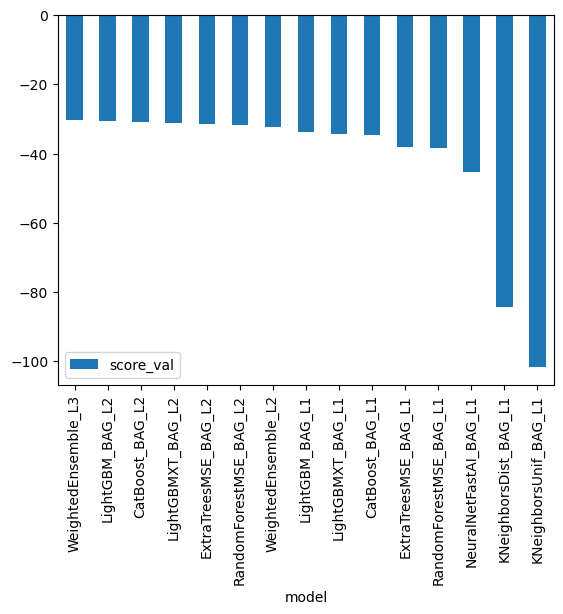

```python
predictor_new_features.leaderboard(silent=True).plot(kind="bar", x="model", y="score_val")
```

```python
predictions_new_features = predictor_new_features.predict(test)
predictions_new_features.head()
```

```
0    16.708227
1    12.848059
2    11.729315
3    10.091619
4     8.810642
Name: count, dtype: float32
```

```python
# Remember to set all negative values to zero
predictions_new_features[predictions_new_features < 0] = 0
```

```python
sum(predictions_new_features[predictions_new_features < 0])
```

```
0
```

```python
predictions_new_features.describe()
```

```
count    6493.000000
mean      163.668259
std       141.927750
min         2.086263
25%        55.129318
50%       125.996109
75%       235.140274
max       833.258667
Name: count, dtype: float64
```

```python
# Same submitting predictions
submission_new_features= submission.copy()
submission_new_features['count'] = predictions_new_features
submission_new_features.to_csv("submission_new_features.csv", index=False)
```

```python
!kaggle competitions submit -c bike-sharing-demand -f submission_new_features.csv -m "new features"
```

```
Successfully submitted to Bike Sharing Demand
```

```
  4%|4         | 8.00k/194k [00:00<00:12, 15.3kB/s]
 70%|######9   | 136k/194k [00:00<00:00, 268kB/s]
```

```python
!kaggle competitions submissions -c bike-sharing-demand | tail -n +1 | head -n 6
```

[output not shown]

## Step 6: Hyper parameter optimization

- There are many options for hyper parameter optimization.
- Options are to change the AutoGluon higher level parameters or the individual model hyperparameters.
- The hyperparameters of the models themselves that are in AutoGluon. Those need the `hyperparameter` and `hyperparameter_tune_kwargs` arguments.

```python
nn = {
    'num_epochs': 10,
    'activation': 'relu',
    'dropout_prob': 0.2
}
```

```python
gbm = {
    'num_boost_round': 1000,
    'learning_rate':0.01
}
```

```python
xgb = {
    "n_estimators": 500,
    'learning_rate': 0.01
}
```

```python
hyperparameters = {
    'NN_TORCH': nn,
    'GBM': gbm,
    'XGB': xgb
}
```

```python
hyperparameter_tune_kwargs = {
    "searcher": "random",
    "scheduler": "local",
    "num_trials": 100,
}
```

```python
predictor_new_hpo = TabularPredictor(label='count',
                                    eval_metric= 'root_mean_squared_error'
                                    ).fit(train_data=train,
                                          time_limit=600,
                                          presets="best_quality",
                                         hyperparameters=hyperparameters,
                                         hyperparameter_tune_kwargs=hyperparameter_tune_kwargs)
```

```
No path specified. Models will be saved in: "AutogluonModels\ag-20240509_150351"
Presets specified: ['best_quality']
Warning: hyperparameter tuning is currently experimental and may cause the process to hang.
Setting dynamic_stacking from 'auto' to True. Reason: Enable dynamic_stacking when use_bag_holdout is disabled. (use_bag_holdout=False)
Stack configuration (auto_stack=True): num_stack_levels=1, num_bag_folds=8, num_bag_sets=1
Dynamic stacking is enabled (dynamic_stacking=True). AutoGluon will try to determine whether the input data is affected by stacked overfitting and enable or disable stacking as a consequence.
Detecting stacked overfitting by sub-fitting AutoGluon on the input data. That is, copies of AutoGluon will be sub-fit on subset(s) of the data. Then, the holdout validation data is used to detect stacked overfitting.
Sub-fit(s) time limit is: 600 seconds.
Starting holdout-based sub-fit for dynamic stacking. Context path is: AutogluonModels\ag-20240509_150351\ds_sub_fit\sub_fit_ho.
Running the sub-fit in a ray process to avoid memory leakage.
Spend 119 seconds for the sub-fit(s) during dynamic stacking.
Time left for full fit of AutoGluon: 481 seconds.
Starting full fit now with num_stack_levels 1.
Beginning AutoGluon training ... Time limit = 481s
AutoGluon will save models to "AutogluonModels\ag-20240509_150351"
=================== System Info ===================
AutoGluon Version:  1.1.0
Python Version:     3.11.5
Operating System:   Windows
Platform Machine:   AMD64
Platform Version:   10.0.22631
CPU Count:          12
Memory Avail:       4.63 GB / 15.74 GB (29.5%)
Disk Space Avail:   8.29 GB / 201.59 GB (4.1%)
	WARNING: Available disk space is low and there is a risk that AutoGluon will run out of disk during fit, causing an exception.
	We recommend a minimum available disk space of 10 GB, and large datasets may require more.
===================================================
Train Data Rows:    10886
Train Data Columns: 13
Label Column:       count
Problem Type:       regression
Preprocessing data ...
Using Feature Generators to preprocess the data ...
Fitting AutoMLPipelineFeatureGenerator...
	Available Memory:                    4730.31 MB
	Train Data (Original)  Memory Usage: 0.77 MB (0.0% of available memory)
	Inferring data type of each feature based on column values. Set feature_metadata_in to manually specify special dtypes of the features.
	Stage 1 Generators:
		Fitting AsTypeFeatureGenerator...
			Note: Converting 3 features to boolean dtype as they only contain 2 unique values.
```

[output cut: 23 more lines]

```
	13 features in original data used to generate 15 features in processed data.
	Train Data (Processed) Memory Usage: 0.76 MB (0.0% of available memory)
Data preprocessing and feature engineering runtime = 0.69s ...
AutoGluon will gauge predictive performance using evaluation metric: 'root_mean_squared_error'
	This metric's sign has been flipped to adhere to being higher_is_better. The metric score can be multiplied by -1 to get the metric value.
	To change this, specify the eval_metric parameter of Predictor()
User-specified model hyperparameters to be fit:
{
	'NN_TORCH': {'num_epochs': 10, 'activation': 'relu', 'dropout_prob': 0.2},
	'GBM': {'num_boost_round': 1000, 'learning_rate': 0.01},
	'XGB': {'n_estimators': 500, 'learning_rate': 0.01},
}
AutoGluon will fit 2 stack levels (L1 to L2) ...
Fitting 3 L1 models ...
Hyperparameter tuning model: LightGBM_BAG_L1 ... Tuning model for up to 96.04s of the 480.31s of remaining time.
```

```
	Fitting 8 child models (S1F1 - S1F8) | Fitting with ParallelLocalFoldFittingStrategy (8 workers, per: cpus=1, gpus=0, memory=0.16%)
	Fitting 8 child models (S1F1 - S1F8) | Fitting with ParallelLocalFoldFittingStrategy (8 workers, per: cpus=1, gpus=0, memory=0.33%)
	Fitting 8 child models (S1F1 - S1F8) | Fitting with ParallelLocalFoldFittingStrategy (8 workers, per: cpus=1, gpus=0, memory=0.18%)
	Fitting 8 child models (S1F1 - S1F8) | Fitting with ParallelLocalFoldFittingStrategy (8 workers, per: cpus=1, gpus=0, memory=0.24%)
	Fitting 8 child models (S1F1 - S1F8) | Fitting with ParallelLocalFoldFittingStrategy (8 workers, per: cpus=1, gpus=0, memory=0.19%)
	Stopping HPO to satisfy time limit...
Fitted model: LightGBM_BAG_L1\T1 ...
	-37.1466	 = Validation score   (-root_mean_squared_error)
	16.62s	 = Training   runtime
	0.0s	 = Validation runtime
Fitted model: LightGBM_BAG_L1\T2 ...
	-35.3005	 = Validation score   (-root_mean_squared_error)
	19.16s	 = Training   runtime
	0.0s	 = Validation runtime
Fitted model: LightGBM_BAG_L1\T3 ...
	-37.8561	 = Validation score   (-root_mean_squared_error)
	15.59s	 = Training   runtime
	0.0s	 = Validation runtime
Fitted model: LightGBM_BAG_L1\T4 ...
	-35.9012	 = Validation score   (-root_mean_squared_error)
	18.62s	 = Training   runtime
	0.0s	 = Validation runtime
Fitted model: LightGBM_BAG_L1\T5 ...
	-37.8034	 = Validation score   (-root_mean_squared_error)
	16.3s	 = Training   runtime
	0.0s	 = Validation runtime
Hyperparameter tuning model: XGBoost_BAG_L1 ... Tuning model for up to 96.04s of the 393.75s of remaining time.
```

[output not shown]

[output cut: 25 more lines]

[output not shown]

```
	Fitting 8 child models (S1F1 - S1F8) | Fitting with ParallelLocalFoldFittingStrategy (8 workers, per: cpus=1, gpus=0, memory=0.31%)
	Fitting 8 child models (S1F1 - S1F8) | Fitting with ParallelLocalFoldFittingStrategy (8 workers, per: cpus=1, gpus=0, memory=0.48%)
	Fitting 8 child models (S1F1 - S1F8) | Fitting with ParallelLocalFoldFittingStrategy (8 workers, per: cpus=1, gpus=0, memory=0.26%)
	Fitting 8 child models (S1F1 - S1F8) | Fitting with ParallelLocalFoldFittingStrategy (8 workers, per: cpus=1, gpus=0, memory=0.36%)
	Fitting 8 child models (S1F1 - S1F8) | Fitting with ParallelLocalFoldFittingStrategy (8 workers, per: cpus=1, gpus=0, memory=0.28%)
	Stopping HPO to satisfy time limit...
Fitted model: LightGBM_BAG_L2\T1 ...
	-35.3924	 = Validation score   (-root_mean_squared_error)
	17.28s	 = Training   runtime
	0.0s	 = Validation runtime
Fitted model: LightGBM_BAG_L2\T2 ...
	-35.432	 = Validation score   (-root_mean_squared_error)
	20.5s	 = Training   runtime
	0.0s	 = Validation runtime
Fitted model: LightGBM_BAG_L2\T3 ...
	-35.3796	 = Validation score   (-root_mean_squared_error)
	16.16s	 = Training   runtime
	0.0s	 = Validation runtime
Fitted model: LightGBM_BAG_L2\T4 ...
	-35.3653	 = Validation score   (-root_mean_squared_error)
	18.62s	 = Training   runtime
	0.0s	 = Validation runtime
Fitted model: LightGBM_BAG_L2\T5 ...
	-35.2614	 = Validation score   (-root_mean_squared_error)
	16.76s	 = Training   runtime
	0.0s	 = Validation runtime
Hyperparameter tuning model: XGBoost_BAG_L2 ... Tuning model for up to 89.93s of the 210.15s of remaining time.
```

[output not shown]

[output cut: 10 more lines]

[output not shown]

```python
predictor_new_hpo.fit_summary()
```

```
*** Summary of fit() ***
Estimated performance of each model:
                  model  score_val              eval_metric  pred_time_val    fit_time  pred_time_val_marginal  fit_time_marginal  stack_level  can_infer  fit_order
0   WeightedEnsemble_L3 -34.894858  root_mean_squared_error       0.005005  256.724897                0.002002           0.111085            3       True         23
1   WeightedEnsemble_L2 -35.194909  root_mean_squared_error       0.000999   71.244053                0.000999           0.075558            2       True         13
2    LightGBM_BAG_L2\T5 -35.261407  root_mean_squared_error       0.003002  196.347874                0.000000          16.762360            2       True         18
3    LightGBM_BAG_L1\T2 -35.300457  root_mean_squared_error       0.000000   19.162244                0.000000          19.162244            1       True          2
4    LightGBM_BAG_L2\T4 -35.365304  root_mean_squared_error       0.003002  198.206061                0.000000          18.620547            2       True         17
5    LightGBM_BAG_L2\T3 -35.379630  root_mean_squared_error       0.003002  195.744965                0.000000          16.159451            2       True         16
6    LightGBM_BAG_L2\T1 -35.392355  root_mean_squared_error       0.003002  196.865872                0.000000          17.280358            2       True         14
7    LightGBM_BAG_L2\T2 -35.431997  root_mean_squared_error       0.003002  200.086362                0.000000          20.500848            2       True         15
8     XGBoost_BAG_L2\T4 -35.434896  root_mean_squared_error       0.003002  194.494355                0.000000          14.908841            2       True         22
9     XGBoost_BAG_L2\T3 -35.660334  root_mean_squared_error       0.004001  198.045329                0.000999          18.459815            2       True         21
10    XGBoost_BAG_L2\T1 -35.724299  root_mean_squared_error       0.003002  195.999665                0.000000          16.414151            2       True         19
11    XGBoost_BAG_L2\T2 -35.799616  root_mean_squared_error       0.003002  205.071454                0.000000          25.485940            2       True         20
12   LightGBM_BAG_L1\T4 -35.901248  root_mean_squared_error       0.000000   18.624872                0.000000          18.624872            1       True          4
13   LightGBM_BAG_L1\T1 -37.146624  root_mean_squared_error       0.000000   16.620886                0.000000          16.620886            1       True          1
14   LightGBM_BAG_L1\T5 -37.803445  root_mean_squared_error       0.001002   16.296123                0.001002          16.296123            1       True          5
15   LightGBM_BAG_L1\T3 -37.856095  root_mean_squared_error       0.000000   15.589261                0.000000          15.589261            1       True          3
16    XGBoost_BAG_L1\T2 -38.819877  root_mean_squared_error       0.000000   16.760493                0.000000          16.760493            1       True          7
17    XGBoost_BAG_L1\T1 -42.697013  root_mean_squared_error       0.000000   13.314663                0.000000          13.314663            1       True          6
18    XGBoost_BAG_L1\T3 -43.850438  root_mean_squared_error       0.001002   13.469183                0.001002          13.469183            1       True          8
19    XGBoost_BAG_L1\T4 -51.038598  root_mean_squared_error       0.000998   13.660023                0.000998          13.660023            1       True          9
20    XGBoost_BAG_L1\T7 -60.877905  root_mean_squared_error       0.000000   11.705862                0.000000          11.705862            1       True         12
21    XGBoost_BAG_L1\T6 -61.581581  root_mean_squared_error       0.000000   12.473727                0.000000          12.473727            1       True         11
22    XGBoost_BAG_L1\T5 -77.703920  root_mean_squared_error       0.000000   11.908178                0.000000          11.908178            1       True         10
Number of models trained: 23
Types of models trained:
{'WeightedEnsembleModel', 'StackerEnsembleModel_XGBoost', 'StackerEnsembleModel_LGB'}
Bagging used: True  (with 8 folds)
Multi-layer stack-ensembling used: True  (with 3 levels)
Feature Metadata (Processed):
(raw dtype, special dtypes):
('category', [])             : 2 | ['season', 'weather']
('float', [])                : 3 | ['temp', 'atemp', 'windspeed']
('int', [])                  : 4 | ['humidity', 'month', 'day', 'hour']
('int', ['bool'])            : 3 | ['holiday', 'workingday', 'year']
('int', ['datetime_as_int']) : 3 | ['datetime', 'datetime.year', 'datetime.dayofweek']
Plot summary of models saved to file: AutogluonModels\ag-20240509_150351SummaryOfModels.html
*** End of fit() summary ***
```

[output not shown]

[output cut: 229 more lines]

[output not shown]

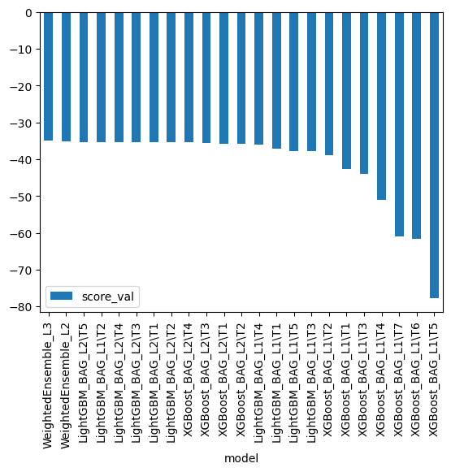

```python
predictor_new_hpo.leaderboard(silent=True).plot(kind="bar", x="model", y="score_val")
```

```python
predictions_new_hpo = predictor_new_hpo.predict(test)
predictions_new_hpo.head()
```

```
0    13.508836
1     4.491531
2     2.513617
3     3.383483
4     3.381416
Name: count, dtype: float32
```

```python
# Remember to set all negative values to zero
predictions_new_hpo[predictions_new_hpo < 0] = 0
```

```python
sum(predictions_new_hpo[predictions_new_hpo < 0])
```

```
0
```

```python
predictions_new_hpo.describe()
```

```
count    6493.000000
mean      192.485260
std       173.906586
min         0.000000
25%        47.685623
50%       148.053970
75%       287.722504
max       887.799194
Name: count, dtype: float64
```

```python
# Same submitting predictions
submission_new_hpo = submission.copy()
submission_new_hpo["count"] = predictions_new_hpo
submission_new_hpo.to_csv("submission_new_hpo.csv", index=False)
```

```python
!kaggle competitions submit -c bike-sharing-demand -f submission_new_hpo.csv -m "new features with hyperparameters"
```

```
Successfully submitted to Bike Sharing Demand
```

```
  4%|4         | 8.00k/194k [00:00<00:12, 15.6kB/s]
 74%|#######4  | 144k/194k [00:00<00:00, 288kB/s]
```

```python
!kaggle competitions submissions -c bike-sharing-demand | tail -n +1 | head -n 6
```

[output not shown]

## Step 7: Write a Report

### Refer to the markdown file for the full report

### Creating plots and table for report

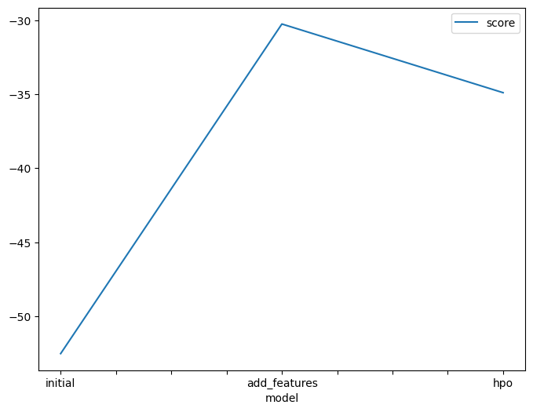

```python
# Taking the top model score from each training run and creating a line plot to show improvement
# You can create these in the notebook and save them to PNG or use some other tool (e.g. google sheets, excel)
fig = pd.DataFrame(
    {
        "model": ["initial", "add_features", "hpo"],
        "score": [predictor.leaderboard(silent=True)["score_val"][0], predictor_new_features.leaderboard(silent=True)["score_val"][0], predictor_new_hpo.leaderboard(silent=True)["score_val"][0]]
    }
).plot(x="model", y="score", figsize=(8, 6)).get_figure()
fig.savefig('model_train_score.png')
```

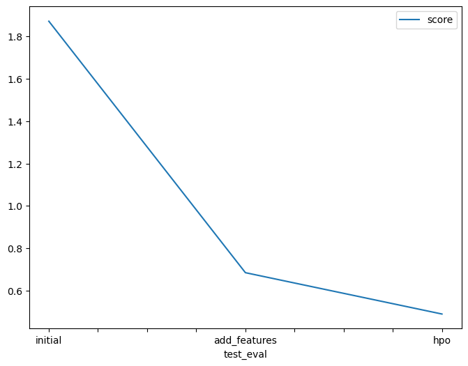

```python
# Take the 3 kaggle scores and creating a line plot to show improvement
fig = pd.DataFrame(
    {
        "test_eval": ["initial", "add_features", "hpo"],
        "score": [1.87097, 0.68536, 0.49040]
    }
).plot(x="test_eval", y="score", figsize=(8, 6)).get_figure()
fig.savefig('model_test_score.png')
```

### Hyperparameter table

```python
# The 3 hyperparameters we tuned with the kaggle score as the result
pd.DataFrame({
    "model": ["initial", "add_features", "hpo"],
    "NN_TORCH": ["default_values", "default_values", {'num_epochs': 10, 'activation': 'relu', 'dropout_prob': 0.2}],
    "GBM": ["default_values", "default_values", {'num_boost_round': 1000, 'learning_rate': 0.01}],
    "XGB": ["default_values", "default_values", {'n_estimators': 500, 'learning_rate': 0.01}],
    "score": [1.87097, 0.68536, 0.49040]
})
```

|  | model | NN_TORCH | GBM | XGB | score |
| --- | --- | --- | --- | --- | --- |
| 0 | initial | default_values | default_values | default_values | 1.87097 |
| 1 | add_features | default_values | default_values | default_values | 0.68536 |
| 2 | hpo | {'num_epochs': 10, 'activation': 'relu', 'dropout_prob': 0.2} | {'num_boost_round': 1000, 'learning_rate': 0.01} | {'n_estimators': 500, 'learning_rate': 0.01} | 0.49040 |